# Part 2 of Final Project

Chloe Seeborg

April 7, 2024

```r
# imports
library(tidyverse)
library(sf)
library(tmap)
```

## Tidying the Data

### Question 1

My analysis will only use one dataset, the anthromes dataset. The CRS for it is WGS 84.

```r
anthromes <- read_sf("C:/geog4870/finalproject/anthromes/an12_dgg_complete.shp")
print(st_crs(anthromes))
```

```
## Coordinate Reference System:
##   User input: WGS 84
##   wkt:
## GEOGCRS["WGS 84",
##     DATUM["World Geodetic System 1984",
##         ELLIPSOID["WGS 84",6378137,298.257223563,
##             LENGTHUNIT["metre",1]]],
##     PRIMEM["Greenwich",0,
##         ANGLEUNIT["degree",0.0174532925199433]],
##     CS[ellipsoidal,2],
##         AXIS["latitude",north,
##             ORDER[1],
##             ANGLEUNIT["degree",0.0174532925199433]],
##         AXIS["longitude",east,
##             ORDER[2],
##             ANGLEUNIT["degree",0.0174532925199433]],
##     ID["EPSG",4326]]
```

### Question 2

Since I am only using one dataset, there is not need to do any integration. However, there are a few things that I would like to do to the data.

First, there are 75 columns in the data that correspond to time periods ranging from 10,000 BC to 2017 AD. I am going to use dplyr to select only a few time periods. I am going to create a new shapefile with the time periods 1700AD, 1800AD, 1900AD, and 2000AD. I am also renaming the columns so they don’t start with numbers. The creation of the shapefile is commented out so that the document can knit properly.

```r
anth <- anthromes %>%
  select(id, land_ar, pot_veg, pot_vll, regn_nm, `1700AD`, `1800AD`, `1900AD`,
         `2000AD`, geometry) %>%
  rename(AD1700 = `1700AD`, AD1800 = `1800AD`, AD1900 = `1900AD`,
         AD2000 = `2000AD`)
# st_write(anth, "anth.shp")
```

The next thing that I would like to do is to reclassify the land use values to 0 (not developed), and 1 (developed). This will be important to analyze where undeveloped land is clustered.

Based on the flowchart for the land use classification made by the Anthromes authors, I have decided to reclassify the land use in this way:

Developed: [11, 12, 21, 22, 23, 24, 31, 32, 33, 34, 41, 42, 51, 52, 54] Not Developed: [43, 53, 61, 62, 63]

Here is the flowchart:

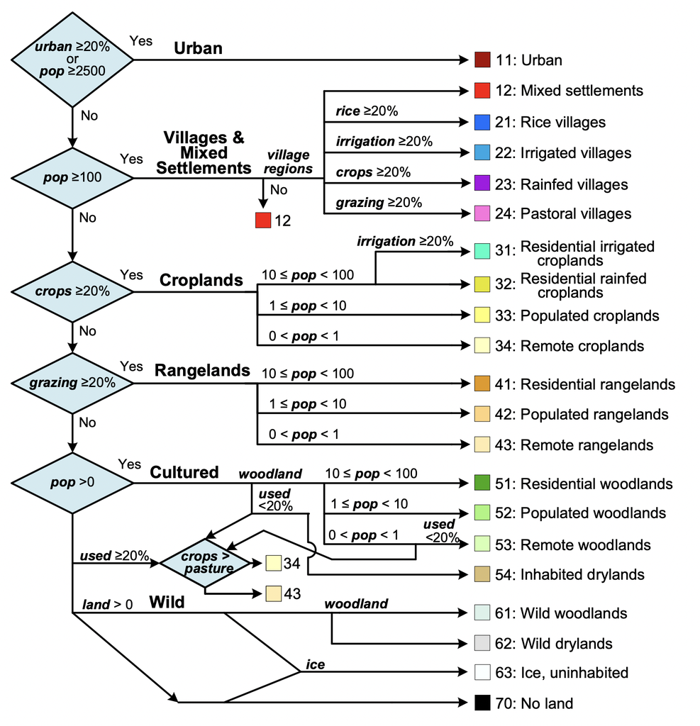

Anthromes Flowchart

```r
# duplicate anth object so we don't alter the original
anth_reclass <- anth
# Define the reclassification function
reclass_land_use <- function(x) {
  x_reclassified <- ifelse(x %in% c(11, 12, 21, 22, 23, 24, 31, 32, 33, 34, 41,
                                    42, 51, 52, 54), 1, 0)
  return(x_reclassified)
}
# define columns to reclassify
land_use_columns <- c("AD1700", "AD1800", "AD1900", "AD2000")
# reclassify columns using for loop
for (column in land_use_columns){
  anth_reclass[[column]] <- reclass_land_use(anth_reclass[[column]])
}
```

### Question 3

I am going to subset the data into two of the time periods, 1900 and 2000, and plot them.

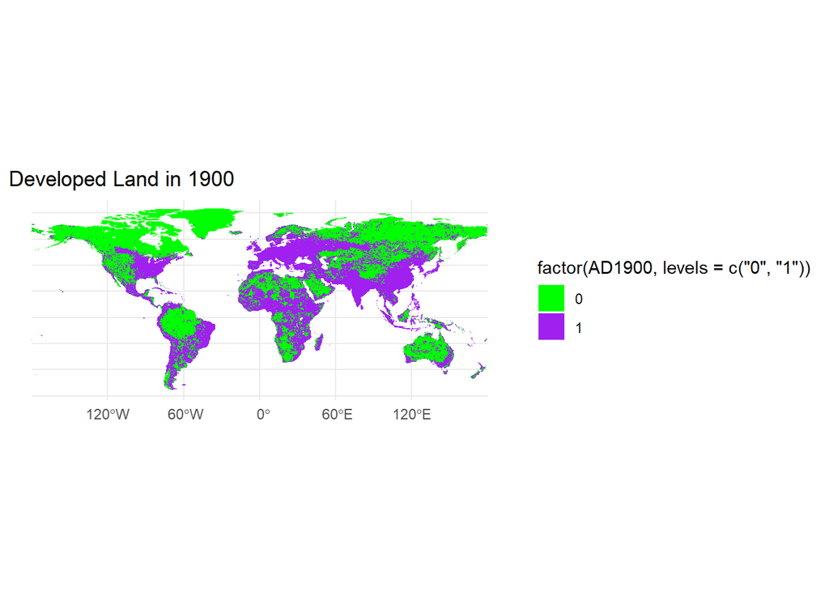

```r
# subset 1900
anth_1900 <- anth_reclass %>%
  select(AD1900, geometry)
# change land use to factor for plotting
anth_1900$AD1900 <- as.factor(anth_1900$AD1900)
# plot 1900
ggplot(anth_1900) +
  geom_sf(aes(fill = factor(AD1900, levels = c("0", "1"))), color = NA) +
  scale_fill_manual(values = c("green", "purple")) +
  labs(title = "Developed Land in 1900") +
  theme_minimal()
```

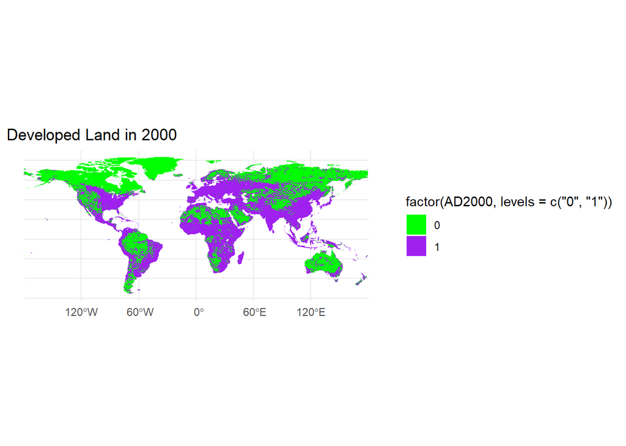

```r
# subset 2000
anth_2000 <- anth_reclass %>%
  select(AD2000, geometry)
# change land use to factor for plotting
anth_2000$AD2000 <- as.factor(anth_2000$AD2000)
# plot 2000
ggplot(anth_2000) +
  geom_sf(aes(fill = factor(AD2000, levels = c("0", "1"))), color = NA) +
  scale_fill_manual(values = c("green", "purple")) +
  labs(title = "Developed Land in 2000") +
  theme_minimal()
```

### Question 4

I am going to create a new spatial object, defining North America as my region of interest.

```r
anth_NA <- anth_reclass %>%
  filter(regn_nm == "North America")
# convert land use to factor for plotting in next questions
anth_NA$AD1700 <- as.factor(anth_NA$AD1700)
anth_NA$AD1800 <- as.factor(anth_NA$AD1800)
anth_NA$AD1900 <- as.factor(anth_NA$AD1900)
anth_NA$AD2000 <- as.factor(anth_NA$AD2000)
```

## Visualizing the Data

### Question 5

Throughout all four time periods, the developed land is focused in the continental United States, with much of Canada and Greenland undeveloped. It makes sense that this land remains mostly undeveloped throughout time because it is not as useful to humans to develop. These cold areas are not suited for agriculture, which is the most common type of land conversion globally.

1800 shows a bug expansion of the developed land on the east coast of the US. The arrival of colonial English settlers explains this expansion.

In 1900, the amount of developed land seems to decrease in the western US. My guess for this change is that the land was no longer controlled by Native Americans, which would have been classified as “developed” as it was occupied by humans. Come 1900, much of the land in the western US would instead be remote rangelands and woodlands. Under the reclassification that I performed, this land would be considered undeveloped.

As expected, through time the areas of developed land expand into the areas of undeveloped land.

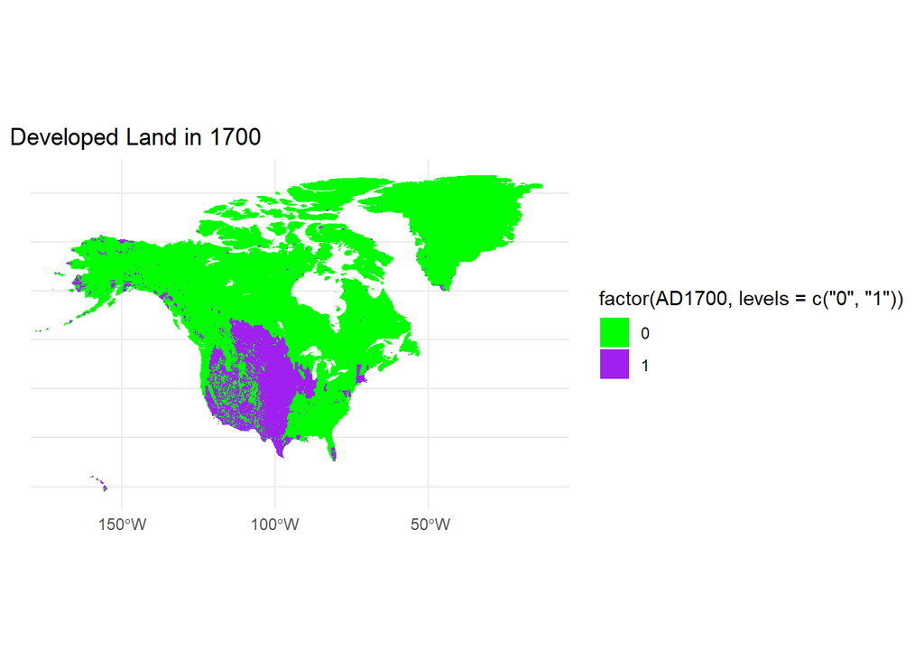

```r
# plot 1700 for NA
ggplot(anth_NA) +
  geom_sf(aes(fill = factor(AD1700, levels = c("0", "1"))), color = NA) +
  scale_fill_manual(values = c("green", "purple")) +
  labs(title = "Developed Land in 1700") +
  theme_minimal()
```

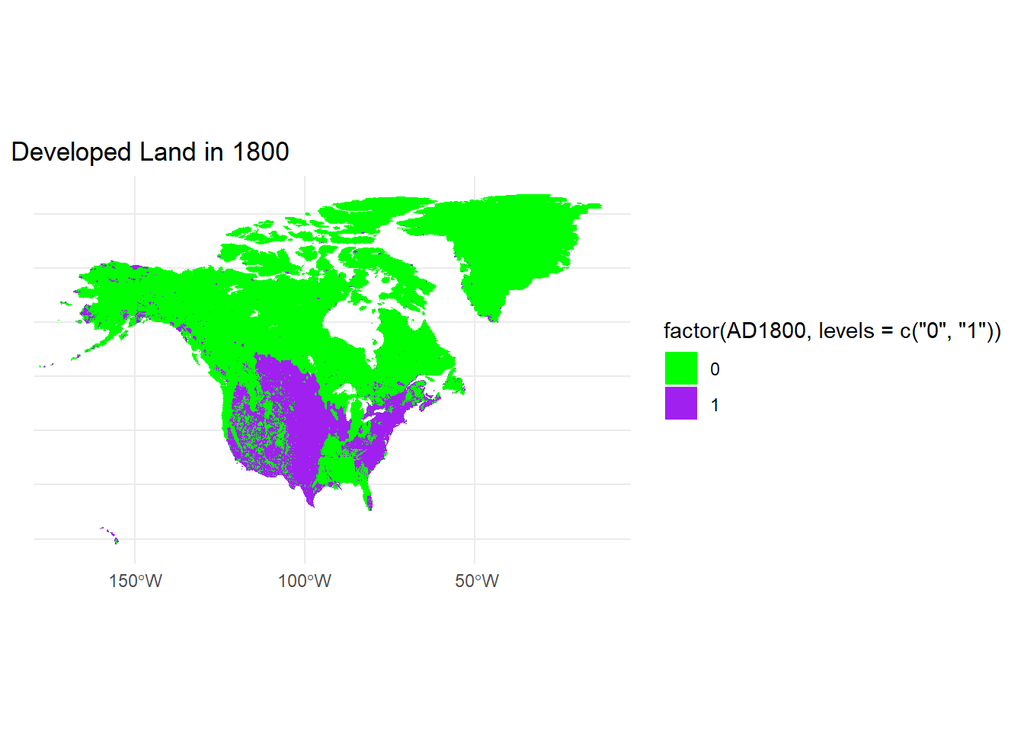

```r
# plot 1800 for NA
ggplot(anth_NA) +
  geom_sf(aes(fill = factor(AD1800, levels = c("0", "1"))), color = NA) +
  scale_fill_manual(values = c("green", "purple")) +
  labs(title = "Developed Land in 1800") +
  theme_minimal()
```

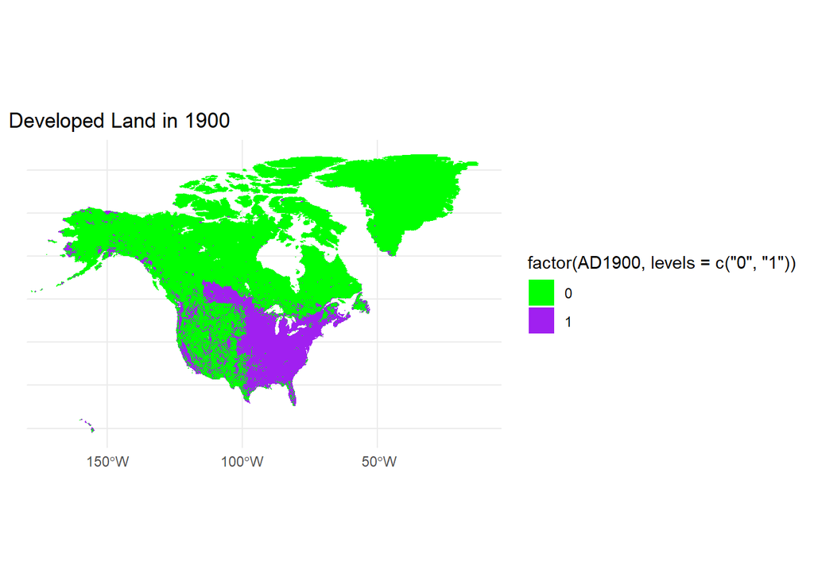

```r
# plot 1900 for NA
ggplot(anth_NA) +
  geom_sf(aes(fill = factor(AD1900, levels = c("0", "1"))), color = NA) +
  scale_fill_manual(values = c("green", "purple")) +
  labs(title = "Developed Land in 1900") +
  theme_minimal()
```

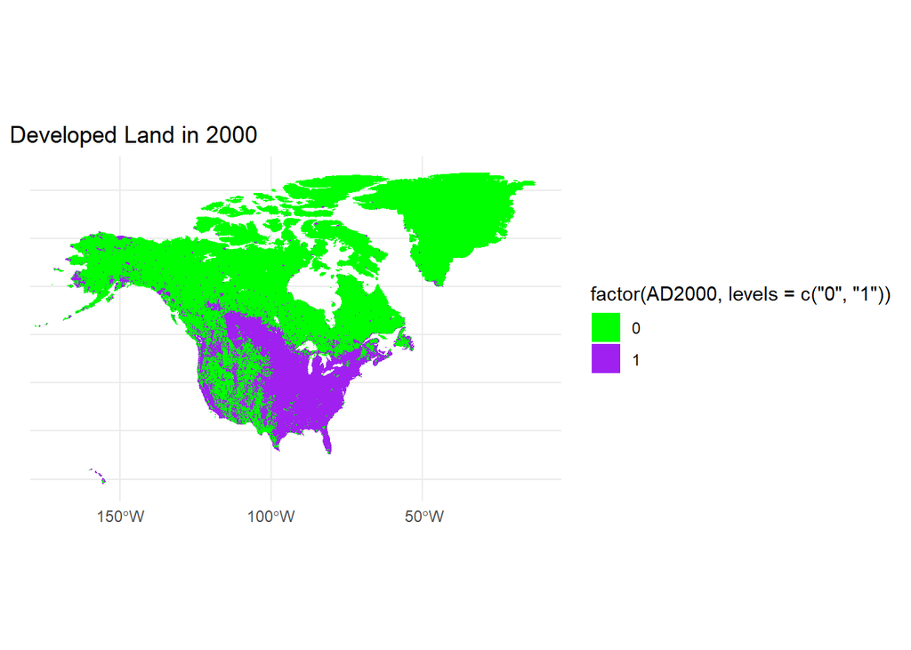

```r
# plot 2000 for NA
ggplot(anth_NA) +
  geom_sf(aes(fill = factor(AD2000, levels = c("0", "1"))), color = NA) +
  scale_fill_manual(values = c("green", "purple")) +
  labs(title = "Developed Land in 2000") +
  theme_minimal()
```

### Question 6

This is the same visualization as before, just built using tmap instead of ggplot2. We can see the same patterns as in question 5.

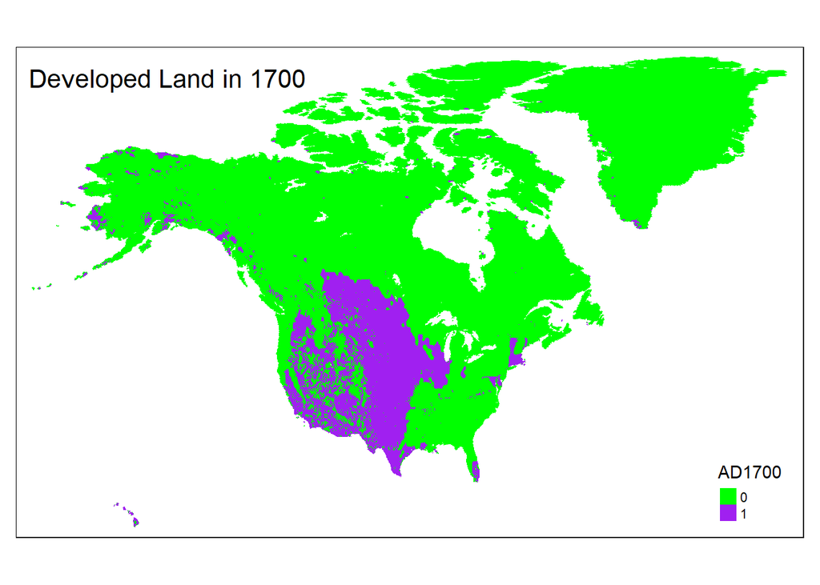

```r
# plot 1700 for NA
tm_shape(anth_NA) +
  tm_fill("AD1700", palette = c("green", "purple")) +
  tm_borders(col = "transparent") +
  tm_layout(title = "Developed Land in 1700")
```

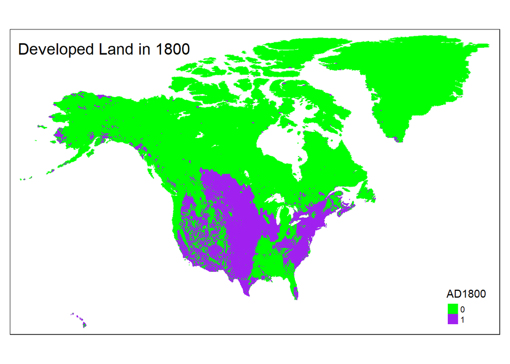

```r
# plot 1800 for NA
tm_shape(anth_NA) +
  tm_fill("AD1800", palette = c("green", "purple")) +
  tm_borders(col = "transparent") +
  tm_layout(title = "Developed Land in 1800")
```

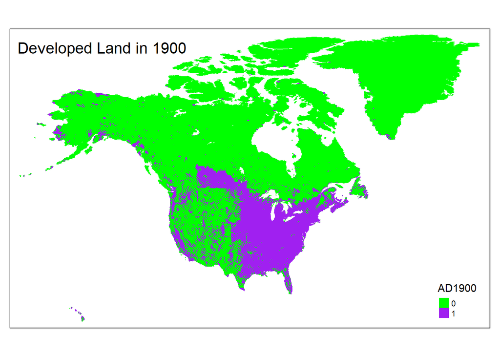

```r
# plot 1900 for NA
tm_shape(anth_NA) +
  tm_fill("AD1900", palette = c("green", "purple")) +
  tm_borders(col = "transparent") +
  tm_layout(title = "Developed Land in 1900")
```

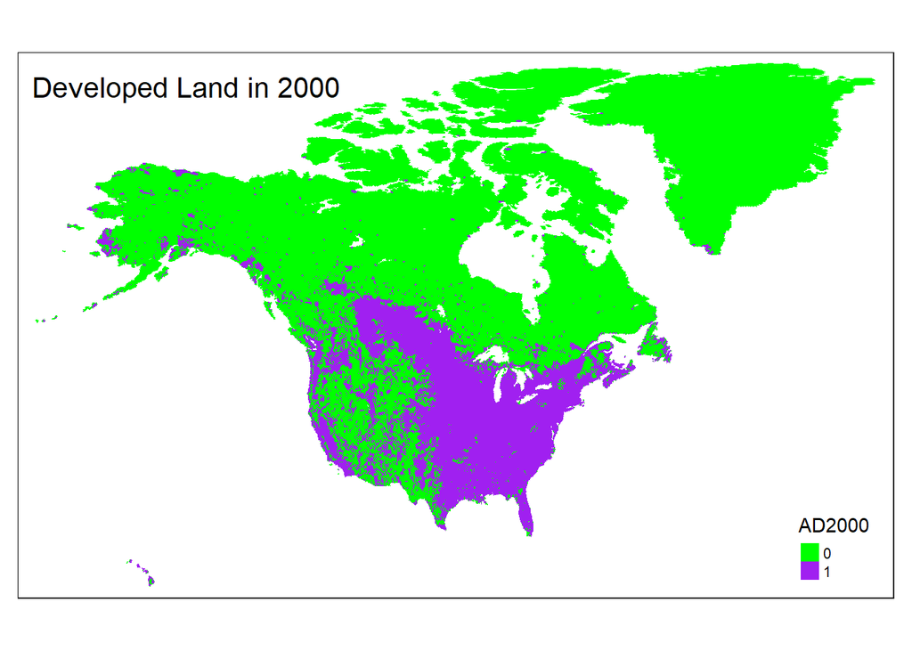

```r
# plot 2000 for NA
tm_shape(anth_NA) +
  tm_fill("AD2000", palette = c("green", "purple")) +
  tm_borders(col = "transparent") +
  tm_layout(title = "Developed Land in 2000")
```